# Occupational Mobility April 2022

Ken-Hou Lin

07 April, 2022

# Overview

This memo explores the directions discussed in the meeting on 3/23.

# Occupation-level trends of co-presence and mobility

## Trends

Matt mentioned that we should look into what the trends look like if we analyze at the occupation level. While my ultimate goal is to formulate a relational model regarding occupational mobility, it is certainly useful to take a look at the occupational level trends.

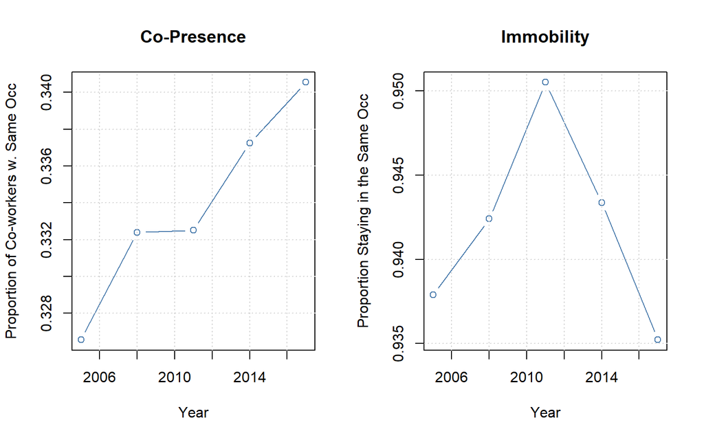

```r
same<-read_dta("SAME_OCC_COPRESENCE_IMMOBILITY.dta")

homo<-rep(0,5)
imm<-rep(0,5)
for (i in 1:5){
  homo[i]<-weighted.mean(same[,i+2],same[,i*2+9])
  imm[i]<-weighted.mean(same[,i*2+8],same[,i*2+9])
}

par(mfrow=c(1,2))
plot(seq(2005,2017,3),homo,type="b",col=pcolor1[1],
     xlab="Year",ylab="Proportion of Co-workers w. Same Occ",main="Co-Presence")
grid()
plot(seq(2005,2017,3),imm,type="b",col=pcolor1[1],
     xlab="Year",ylab="Proportion Staying in the Same Occ",main="Immobility")
grid()
```

The two plots, respectively, show the proportion of co-workers with the same occupation, and the proportion of workers staying in the same occupation in two consecutive years. The patterns are consistent with what we saw last time and with Elizabeth’s paper on occupational homogeneity. There has been an increase, albeit small, in the proportion of co-workers with the same occupation. Immobility was highest during the recession.

I should note that, when I model mobility, I exclude diagonal observations where the origin and destination occupations are the same. The concern is that it would certainly pull the coefficients toward our hypotheses (e.g., skill similarity and co-presence lead to mobility). Arguably, one could state that immobility is also a form of mobility and be against the exclusion of diagonal observations.

## Extremes

### Most Same Occupations

```r
homo_thresh<-quantile(same$homo2017, c(0.1, 0.9))
print(same$B[same$homo2017>homo_thresh[2]])
```

```
## [1] "Home Health and Personal Care Aides; and Nursing Assistants, Orderlies, and Psychiatric Aides"
## [2] "Firefighting and Prevention Workers"
## [3] "Other Protective Service Workers"
## [4] "Food and Beverage Serving Workers"
## [5] "Grounds Maintenance Workers"
## [6] "Personal Appearance Workers"
## [7] "Agricultural Workers"
## [8] "Construction Trades Workers"
## [9] "Water Transportation Workers"
```

The list seems quite reasonable to me. I am not sure what else to say other than none requires a lot of formal education.

### Least Same Occupations

```r
print(same$B[same$homo2017<homo_thresh[1]])
```

```
## [1] "Top Executives"
## [2] "Advertising, Marketing, Promotions, Public Relations, and Sales Managers"
## [3] "Supervisors of Protective Service Workers"
## [4] "Supervisors of Personal Care and Service Workers"
## [5] "Supervisors of Office and Administrative Support Workers"
## [6] "Supervisors of Farming, Fishing, and Forestry Workers"
## [7] "Supervisors of Installation, Maintenance, and Repair Workers"
## [8] "Supervisors of Production Workers"
## [9] "Supervisors of Transportation and Material Moving Workers"
```

Again, not surprising that managers and supervisors don’t have a lot of co-workers holding the same position in the establishment.

### Least Mobile Occupations

```r
mob_thresh<-quantile(same$flow2017, c(0.1, 0.9))
print(same$B[same$flow2017>mob_thresh[2]])
```

```
## [1] "Top Executives"
## [2] "Computer Occupations"
## [3] "Engineers"
## [4] "Social Scientists and Related Workers"
## [5] "Lawyers, Judges, and Related Workers"
## [6] "Healthcare Diagnosing or Treating Practitioners"
## [7] "Supervisors of Protective Service Workers"
## [8] "Firefighting and Prevention Workers"
## [9] "Law Enforcement Workers"
```

Workers of these occupations are most likely to stay in their occupations. Not really surprising here since most are desirable and/or very secured occupations. I do think the fact that social scientists have very stable jobs leads us to underestimate how much occupational changes there are.

### Most Mobile Occupations

```r
print(same$B[same$flow2017<mob_thresh[1]])
```

```
## [1] "Other Food Preparation and Serving Related Workers"
## [2] "Entertainment Attendants and Related Workers"
## [3] "Tour and Travel Guides"
## [4] "Communications Equipment Operators"
## [5] "Fishing and Hunting Workers"
## [6] "Forest, Conservation, and Logging Workers"
## [7] "Helpers, Construction Trades"
## [8] "Extraction Workers"
## [9] "Woodworkers"
```

Communications Equipment Operators, I believe, are call center workers, dispatcher, and receptionists. The list seems quite reasonable. Some mobility in agriculture could be due to seasonality. These are in general not very stable employment that could be temporary.

## Individual Occupation Checks

Here I check a number of occupations to find where their workers come from (feeders) and where their workers go to (takers). I also check with which occupations they work with. It’s not obvious which occupations I should select but I will just pick Social Scientists, Lawyers, Doctors, Cooks, and Secretaries. I honestly am not sure whether the finding in this section is useful so you may want to skip to the next section if you find the description tedious.

First, to get some benchmarks for mobility and co-presence, let’s look at their distributions

```r
wide<-read_dta("CPS_OES_3YR_WIDE.dta")
round(quantile(wide$exp2017,seq(0,1,0.1)),digit=8)
```

```
##         0%        10%        20%        30%        40%        50%        60%
## 0.00000000 0.00002150 0.00008226 0.00021862 0.00047736 0.00102160 0.00197860
##        70%        80%        90%       100%
## 0.00397561 0.00823705 0.01909960 0.53870081
```

```r
round(quantile(wide$flow2017,seq(0,1,0.1)),digit=8)
```

```
##         0%        10%        20%        30%        40%        50%        60%
## 0.00000000 0.00000000 0.00000000 0.00000000 0.00000000 0.00000000 0.00000000
##        70%        80%        90%       100%
## 0.00000000 0.00043006 0.00160697 0.16697783
```

The median for co-presence is about 0.001 and the 90th percentile is about 0.02.It just shows that there are clusters of occupations in different types of establishments. The median for flow is 0 and the 90th percentile is 0.001. As expected, both are super skewed.

### Social Scientists (193000)

```r
feeder<-subset(wide,wide$receive==193000)
mob_thresh<-quantile(feeder$flow2017, c(0.95))
print(rbind(feeder$B[feeder$flow2017>mob_thresh],
            feeder$flow2017[feeder$flow2017>mob_thresh]))
```

```
##      [,1]                           [,2]
## [1,] "Other Management Occupations" "Business Operations Specialists"
## [2,] "0.000195361007994841"         "0.000272248285845383"
##      [,3]
## [1,] "Architects, Surveyors, and Cartographers"
## [2,] "0.00399557549443431"
##      [,4]
## [1,] "Counselors, Social Workers, and Other Community and Social Service Specialists"
## [2,] "0.000592406343667751"
##      [,5]
## [1,] "Postsecondary Teachers"
## [2,] "0.00104077870701521"
```

The are the top five occupations where workers are most likely to become social scientists. The list seems reasonable to me, but it also shows that Social Scientists is a super crude category.

```r
taker<-subset(wide,wide$send==193000)
mob_thresh<-quantile(taker$flow2017, c(0.95))
print(rbind(taker$D[taker$flow2017>mob_thresh],
            taker$flow2017[taker$flow2017>mob_thresh]))
```

```
##      [,1]
## [1,] "Advertising, Marketing, Promotions, Public Relations, and Sales Managers"
## [2,] "0.00296905783899713"
##      [,2]
## [1,] "Other Management Occupations"
## [2,] "0.0074497668560828"
##      [,3]
## [1,] "Counselors, Social Workers, and Other Community and Social Service Specialists"
## [2,] "0.00519901624074534"
##      [,4]
## [1,] "Lawyers, Judges, and Related Workers"
## [2,] "0.00324729356827906"
##      [,5]
## [1,] "Retail Sales Workers and Sales Representatives"
## [2,] "0.00256044790435582"
```

These are the top five destinations for social scientists. They again seem reasonable but very low probabilities in general. I also wonder which occupations are counted as Social Scientists.

```r
co<-subset(wide,wide$send==193000)
co_thresh<-quantile(co$exp2017, c(0.95))
print(rbind(co$D[co$exp2017>co_thresh],
            co$exp2017[co$exp2017>co_thresh]))
```

```
##      [,1]                              [,2]
## [1,] "Business Operations Specialists" "Computer Occupations"
## [2,] "0.0501113417276609"              "0.0328424697382832"
##      [,3]
## [1,] "Counselors, Social Workers, and Other Community and Social Service Specialists"
## [2,] "0.0868784801686506"
##      [,4]
## [1,] "Healthcare Diagnosing or Treating Practitioners"
## [2,] "0.0712536740675706"
##      [,5]
## [1,] "Secretaries and Administrative Assistants"
## [2,] "0.0545983482266369"
```

These are the top occupations that share the same establishment with social scientists. The health care one is most surprising to me. I would also expect there to be more other scientists since I am in an academic setting. It could be there are more social scientists involved in direct-service than I realize or many Social Scientists are social workers.

### Lawyers, Judges, and Related Workers (231000)

```r
feeder<-subset(wide,wide$receive==231000)
mob_thresh<-quantile(feeder$flow2017, c(0.95))
print(rbind(feeder$B[feeder$flow2017>mob_thresh],
            feeder$flow2017[feeder$flow2017>mob_thresh]))
```

```
##      [,1]
## [1,] "Mathematical Science Occupations"
## [2,] "0.015591715472947"
##      [,2]
## [1,] "Drafters, Engineering Technicians, and Mapping Technicians"
## [2,] "0.00628668703764287"
##      [,3]                  [,4]                    [,5]
## [1,] "Physical Scientists" "Legal Support Workers" "Funeral Service Workers"
## [2,] "0.00325421798195388" "0.00772659682310829"   "0.0042550235209592"
```

The are the top five occupations where workers are most likely to become lawyers. Honestly I don’t know what to expect here. The probabilities are also very low, maybe except for mathematician. Is there a math-law pipeline that I am not aware of?

```r
taker<-subset(wide,wide$send==231000)
mob_thresh<-quantile(taker$flow2017, c(0.95))
print(rbind(taker$D[taker$flow2017>mob_thresh],
            taker$flow2017[taker$flow2017>mob_thresh]))
```

```
##      [,1]                           [,2]
## [1,] "Other Management Occupations" "Business Operations Specialists"
## [2,] "0.00354142860755568"          "0.0019606534131433"
##      [,3]
## [1,] "Preschool, Elementary, Middle, Secondary, and Special Education Teachers"
## [2,] "0.00228185400773123"
##      [,4]
## [1,] "Media and Communication Workers"
## [2,] "0.000708764502125309"
##      [,5]
## [1,] "Healthcare Diagnosing or Treating Practitioners"
## [2,] "0.00564857448921893"
```

These are the top five destinations for lawyers. Again, very low probabilities for lawyers to transition out in general.

```r
co<-subset(wide,wide$send==231000)
co_thresh<-quantile(co$exp2017, c(0.95))
print(rbind(co$D[co$exp2017>co_thresh],
            co$exp2017[co$exp2017>co_thresh]))
```

```
##      [,1]                              [,2]
## [1,] "Business Operations Specialists" "Legal Support Workers"
## [2,] "0.0402359817648898"              "0.1635337168001"
##      [,3]
## [1,] "Information and Record Clerks"
## [2,] "0.0383480709964331"
##      [,4]
## [1,] "Secretaries and Administrative Assistants"
## [2,] "0.140919408844015"
##      [,5]
## [1,] "Other Office and Administrative Support Workers"
## [2,] "0.0349025723953183"
```

The list here is very reasonable. Lawyers work with clerks, secretaries, and legal supports.

### Healthcare Diagnosing or Treating Practitioners (291000)

```r
feeder<-subset(wide,wide$receive==291000)
mob_thresh<-quantile(feeder$flow2017, c(0.95))
print(rbind(feeder$B[feeder$flow2017>mob_thresh],
            feeder$flow2017[feeder$flow2017>mob_thresh]))
```

```
##      [,1]
## [1,] "Mathematical Science Occupations"
## [2,] "0.005961602323245"
##      [,2]
## [1,] "Life, Physical, and Social Science Technicians"
## [2,] "0.00822609045419207"
##      [,3]
## [1,] "Lawyers, Judges, and Related Workers"
## [2,] "0.00564857448921893"
##      [,4]
## [1,] "Occupational Therapy and Physical Therapist Assistants and Aides"
## [2,] "0.01245580155865"
##      [,5]
## [1,] "Animal Care and Service Workers"
## [2,] "0.0076392646183192"
```

Occupations most likely to send workers to become a doctor. Occupational and Physical Therapist Assistants seem very related, as well as Life Science Technicians. It’s interesting how mathematicians keep showing up.

```r
taker<-subset(wide,wide$send==291000)
mob_thresh<-quantile(taker$flow2017, c(0.95))
print(rbind(taker$D[taker$flow2017>mob_thresh],
            taker$flow2017[taker$flow2017>mob_thresh]))
```

```
##      [,1]
## [1,] "Other Management Occupations"
## [2,] "0.00126362000810474"
##      [,2]
## [1,] "Counselors, Social Workers, and Other Community and Social Service Specialists"
## [2,] "0.00136575171016723"
##      [,3]                                   [,4]
## [1,] "Lawyers, Judges, and Related Workers" "Postsecondary Teachers"
## [2,] "0.0020334532883279"                   "0.000428906768730551"
##      [,5]
## [1,] "Health Technologists and Technicians"
## [2,] "0.00182166705924702"
```

All very low probabilities as destinations.

```r
co<-subset(wide,wide$send==291000)
co_thresh<-quantile(co$exp2017, c(0.95))
print(rbind(co$D[co$exp2017>co_thresh],
            co$exp2017[co$exp2017>co_thresh]))
```

```
##      [,1]
## [1,] "Health Technologists and Technicians"
## [2,] "0.129238302916451"
##      [,2]
## [1,] "Home Health and Personal Care Aides; and Nursing Assistants, Orderlies, and Psychiatric Aides"
## [2,] "0.0739326132514204"
##      [,3]                                   [,4]
## [1,] "Other Healthcare Support Occupations" "Information and Record Clerks"
## [2,] "0.0613631250895461"                   "0.0461420613424479"
##      [,5]
## [1,] "Secretaries and Administrative Assistants"
## [2,] "0.0450744644527268"
```

The list of co-present occupations is very reasonable for doctors.

### Cooks and Food Preparation Workers (352000)

```r
feeder<-subset(wide,wide$receive==352000)
mob_thresh<-quantile(feeder$flow2017, c(0.95))
print(rbind(feeder$B[feeder$flow2017>mob_thresh],
            feeder$flow2017[feeder$flow2017>mob_thresh]))
```

```
##      [,1]
## [1,] "Supervisors of Food Preparation and Serving Workers"
## [2,] "0.0615625209445723"
##      [,2]
## [1,] "Food and Beverage Serving Workers"
## [2,] "0.0247405858336802"
##      [,3]
## [1,] "Other Food Preparation and Serving Related Workers"
## [2,] "0.0259347512731214"
##      [,4]                          [,5]
## [1,] "Personal Appearance Workers" "Extraction Workers"
## [2,] "0.00391956843528993"         "0.00476523306659022"
```

The top 3 feeders are all in the restaurant industry.

```r
taker<-subset(wide,wide$send==352000)
mob_thresh<-quantile(taker$flow2017, c(0.95))
print(rbind(taker$D[taker$flow2017>mob_thresh],
            taker$flow2017[taker$flow2017>mob_thresh]))
```

```
##      [,1]
## [1,] "Supervisors of Food Preparation and Serving Workers"
## [2,] "0.0287858686509521"
##      [,2]
## [1,] "Food and Beverage Serving Workers"
## [2,] "0.0227299046233958"
##      [,3]
## [1,] "Other Food Preparation and Serving Related Workers"
## [2,] "0.00905710836103215"
##      [,4]
## [1,] "Retail Sales Workers and Sales Representatives"
## [2,] "0.00806125460018242"
##      [,5]
## [1,] "Information and Record Clerks"
## [2,] "0.00446882375489667"
```

The top 2 takers are also in the restaurant industry.

```r
co<-subset(wide,wide$send==352000)
co_thresh<-quantile(co$exp2017, c(0.95))
print(rbind(co$D[co$exp2017>co_thresh],
            co$exp2017[co$exp2017>co_thresh]))
```

```
##      [,1]
## [1,] "Home Health and Personal Care Aides; and Nursing Assistants, Orderlies, and Psychiatric Aides"
## [2,] "0.0168594097127864"
##      [,2]
## [1,] "Supervisors of Food Preparation and Serving Workers"
## [2,] "0.0561130111561845"
##      [,3]
## [1,] "Food and Beverage Serving Workers"
## [2,] "0.297629598305404"
##      [,4]
## [1,] "Other Food Preparation and Serving Related Workers"
## [2,] "0.0941606115470601"
##      [,5]
## [1,] "Retail Sales Workers and Sales Representatives"
## [2,] "0.0636640416627962"
```

The list of co-present occupations is as expected.

### Secretaries and Administrative Assistants (436000)

```r
feeder<-subset(wide,wide$receive==436000)
mob_thresh<-quantile(feeder$flow2017, c(0.95))
print(rbind(feeder$B[feeder$flow2017>mob_thresh],
            feeder$flow2017[feeder$flow2017>mob_thresh]))
```

```
##      [,1]
## [1,] "Other Food Preparation and Serving Related Workers"
## [2,] "0.00317042074044539"
##      [,2]
## [1,] "Supervisors of Personal Care and Service Workers"
## [2,] "0.00367427114348302"
##      [,3]
## [1,] "Supervisors of Office and Administrative Support Workers"
## [2,] "0.00232519417159733"
##      [,4]
## [1,] "Material Recording, Scheduling, Dispatching, and Distributing Workers"
## [2,] "0.0092079910111539"
##      [,5]
## [1,] "Other Office and Administrative Support Workers"
## [2,] "0.0165826571265897"
```

The most clear feeder is Other Office and Administrative Support Workers. It feels like the same occupation and I should probably look into classification details.

```r
taker<-subset(wide,wide$send==436000)
mob_thresh<-quantile(taker$flow2017, c(0.95))
print(rbind(taker$D[taker$flow2017>mob_thresh],
            taker$flow2017[taker$flow2017>mob_thresh]))
```

```
##      [,1]                           [,2]
## [1,] "Other Management Occupations" "Financial Clerks"
## [2,] "0.00353975417172542"          "0.00259879509577036"
##      [,3]
## [1,] "Information and Record Clerks"
## [2,] "0.00384102789037746"
##      [,4]
## [1,] "Material Recording, Scheduling, Dispatching, and Distributing Workers"
## [2,] "0.0176226011851669"
##      [,5]
## [1,] "Other Office and Administrative Support Workers"
## [2,] "0.0327795391410239"
```

The probabilities of transitioning out to these positions are low but they do feel like more upgraded occupations.

```r
co<-subset(wide,wide$send==436000)
co_thresh<-quantile(co$exp2017, c(0.95))
print(rbind(co$D[co$exp2017>co_thresh],
            co$exp2017[co$exp2017>co_thresh]))
```

```
##      [,1]
## [1,] "Business Operations Specialists"
## [2,] "0.046950331344231"
##      [,2]
## [1,] "Healthcare Diagnosing or Treating Practitioners"
## [2,] "0.076651050931937"
##      [,3]
## [1,] "Health Technologists and Technicians"
## [2,] "0.042296781743919"
##      [,4]
## [1,] "Other Healthcare Support Occupations"
## [2,] "0.038905463108828"
##      [,5]
## [1,] "Retail Sales Workers and Sales Representatives"
## [2,] "0.0443442380839739"
```

Secretarial occupation is so generic that we don’t see a clear top co-present occupations

## Brief Summary

Overall the data set has face validity to me, at least to the extent that most results make some sense. It’s also clear that we are working with pretty broad occupational categories and the mobility here is rare and significant. One way for us to obtain more specific occupation is to do create categories based on **both** industries and occupations, assuming that the establishments in the OES are coded by industry. Another possibility is to use more detailed occupations. I will consider this possibility later.

# Correlation and Outliers

I am going to zoom in to the last period (2015-2017) and re-plot the correlation between correlation and mobility. Now we’re shifting back to occupation pairs.As shown below, there is a positive correlation.

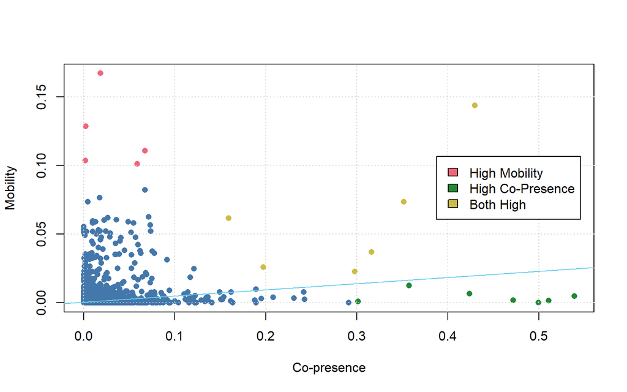

```r
wide$col<-1
wide$col[wide$flow2017>0.1]<-2
wide$col[wide$exp2017>0.3]<-3
wide$col[wide$flow2017>0.02 & wide$exp2017>0.15]<-4
plot(wide$exp2017,wide$flow2017,xlab="Co-presence",ylab="Mobility",col=pcolor1[wide$col],pch=16)
grid()
abline(lm(flow2017 ~ exp2017, data = wide,w=sendsize2017), col=pcolor1[5])
legend("right",c("High Mobility","High Co-Presence","Both High"),inset=0.025, fill=pcolor1[c(2:4)])
```

## High Mobility

I am now looking at three groups of outliers as shown in the plot above. The first group is the pairs with high mobility but low co-presence. The values are arranged in Origin, Destination, Mobility, and Co-presence.

```r
print(rbind(wide$B[wide$col==2], wide$D[wide$col==2],wide$flow2017[wide$col==2],
      wide$exp2017[wide$col==2]))
```

```
##      [,1]
## [1,] "Librarians, Curators, and Archivists"
## [2,] "Other Educational Instruction and Library Occupations"
## [3,] "0.11060896071467"
## [4,] "0.0671201155520642"
##      [,2]                          [,3]
## [1,] "Funeral Service Workers"     "Fishing and Hunting Workers"
## [2,] "Personal Appearance Workers" "Agricultural Workers"
## [3,] "0.103573503164923"           "0.166977826508363"
## [4,] "0.0016146590278706"          "0.018358497146487"
##      [,4]                                        [,5]
## [1,] "Forest, Conservation, and Logging Workers" "Extraction Workers"
## [2,] "Agricultural Workers"                      "Material Moving Workers"
## [3,] "0.128587463478662"                         "0.101180651131603"
## [4,] "0.0022765693998364"                        "0.0587931445112984"
```

1 and 2 clearly can be explained by skill similarities. 3 to 5 seem to be about both skill and being in more rural areas. 3 and 4 could also be capturing something seasonal. Nothing looks particularly surprising here.

## High Co-presence

The second group is those with high co-presence but low mobility. We were expecting there might be some clear educational or licensing barriers.

```r
print(rbind(wide$B[wide$col==3], wide$D[wide$col==3],wide$flow2017[wide$col==3],
      wide$exp2017[wide$col==3]))
```

```
##      [,1]
## [1,] "Occupational Therapy and Physical Therapist Assistants and Aides"
## [2,] "Healthcare Diagnosing or Treating Practitioners"
## [3,] "0.01245580155865"
## [4,] "0.357244815182333"
##      [,2]
## [1,] "Supervisors of Protective Service Workers"
## [2,] "Other Protective Service Workers"
## [3,] "0.0016609877773557"
## [4,] "0.510538404431538"
##      [,3]
## [1,] "Supervisors of Food Preparation and Serving Workers"
## [2,] "Food and Beverage Serving Workers"
## [3,] "0.00188726542862017"
## [4,] "0.471463232003493"
```

[output cut: 20 more lines]

Among these 7 cases, most seem to be about how managers do not experience downward mobility. This kind of confirms our early expectation that co-presence promotes upward but not downward mobility. 1 is directly linked to our discussion that barriers exist to prevent mobility even with high co-presence.

## High Co-presence and High Mobility

```r
print(rbind(wide$B[wide$col==4], wide$D[wide$col==4],wide$flow2017[wide$col==4],
      wide$exp2017[wide$col==4]))
```

```
##      [,1]
## [1,] "Supervisors of Food Preparation and Serving Workers"
## [2,] "Cooks and Food Preparation Workers"
## [3,] "0.0615625209445723"
## [4,] "0.158953113686825"
##      [,2]
## [1,] "Cooks and Food Preparation Workers"
## [2,] "Food and Beverage Serving Workers"
## [3,] "0.0227299046233958"
## [4,] "0.297629598305404"
##      [,3]
## [1,] "Other Food Preparation and Serving Related Workers"
## [2,] "Cooks and Food Preparation Workers"
## [3,] "0.0259347512731214"
## [4,] "0.197339179591978"
##      [,4]
## [1,] "Other Food Preparation and Serving Related Workers"
## [2,] "Food and Beverage Serving Workers"
## [3,] "0.0734444501522801"
## [4,] "0.351209986491534"
##      [,5]                                      [,6]
## [1,] "Funeral Service Workers"                 "Helpers, Construction Trades"
## [2,] "Other Personal Care and Service Workers" "Construction Trades Workers"
## [3,] "0.0368767146704381"                      "0.143510313722682"
## [4,] "0.316090691183875"                       "0.429420388668298"
```

The outliers here are pretty much dominated by the restaurant industry. These cases also confirm our discussion regarding how the effect of co-presence may be most salient for occupations requiring less formal education. As much as the restaurant industry seems trivial, I believe it actually employs a good and growing amount of low-wage workers. In the prior paper, we find that food service has become a clear niche in the labor market.

This is the second time we see a significant amount of mobility out of Funeral Service Workers, which I thought were quite lucrative compared to other service workers but I honestly don’t know much about this industry in the United States.

I will stratify the analysis by education in another analysis.

# Biggest Changes in Co-presence

Here I find the occupation pairs with most changes in co-presence and mobility. I don’t really have any specific hypotheses here.

## Largest Declines

We first examine the 10 highest absolute decline in co-presence.

```r
wide$d_exp<-wide$exp2017-wide$exp2005
wide$d_exp_rank<-rank(wide$d_exp)
sub<-subset(wide,wide$d_exp_rank<=10)
print(rbind(sub$B,sub$D,sub$exp2005,sub$exp2017))
```

```
##      [,1]
## [1,] "Architects, Surveyors, and Cartographers"
## [2,] "Drafters, Engineering Technicians, and Mapping Technicians"
## [3,] "0.174962662353794"
## [4,] "0.13323307907241"
##      [,2]
## [1,] "Lawyers, Judges, and Related Workers"
## [2,] "Secretaries and Administrative Assistants"
## [3,] "0.223966440537889"
## [4,] "0.140919408844015"
##      [,3]
## [1,] "Legal Support Workers"
## [2,] "Secretaries and Administrative Assistants"
## [3,] "0.14324924349947"
## [4,] "0.0885427632492979"
```

[output cut: 35 more lines]

While some of the cases can be understood as a decline in the need for clerical workers, perhaps due to technological changes, most seem to require industry-specific knowledge to make sense.

## Largest Increase

The top 10 increase in co-presence.

```r
wide$d_exp<-wide$exp2017-wide$exp2005
wide$d_exp_rank<-rank(wide$d_exp)
sub<-subset(wide,wide$d_exp_rank>=length(wide$d_exp_rank)-9)
print(rbind(sub$B,sub$D,sub$exp2005,sub$exp2017))
```

```
##      [,1]
## [1,] "Advertising, Marketing, Promotions, Public Relations, and Sales Managers"
## [2,] "Business Operations Specialists"
## [3,] "0.0704646516959785"
## [4,] "0.110235236346687"
##      [,2]
## [1,] "Legal Support Workers"
## [2,] "Lawyers, Judges, and Related Workers"
## [3,] "0.198807501833097"
## [4,] "0.241787359429791"
##      [,3]
## [1,] "Occupational Therapy and Physical Therapist Assistants and Aides"
## [2,] "Healthcare Diagnosing or Treating Practitioners"
## [3,] "0.323124047729643"
## [4,] "0.357244815182333"
```

[output cut: 35 more lines]

In some cases, it seems like the establishments increase the proportion of workers with professional occupations, and in other cases, it seems the opposite. For 4 and 5, I imagine they are related to the expansion of nursing home and criminal justice industries. 6 is probably due to a reduction of communications equipment operators.

# Using CPS ASEC or Monthly CPS

Dave and I had a brief discussion on this topic. The main issue of using monthly CPS is that individuals are no longer observed once they leave the households and the attrition is likely correlated with occupational mobility. In the ASEC, both the current job and the previous job (longest job held last year) are collected at the same time point.

# Co-Presence Effect by Educational Barriers.

This section I test how the correlation between co-presence and mobility vary by educational barriers. I classify the occupations into 3 classes based on the mode of education.

- **Professional**: The modal worker has a postgraduate degree.
- **College**: The modal worker has a 4-year college degree.
- **Non-credential**: Any other occupations.

This creates 9 possible combinations for mobility. We would expect that mobility to be higher among occupations within the same class. It’s probably higher among non-credential occupations and college occupations than professional occupations since the latter are more specialized.

```r
e<-read_dta("mobility_by_educ.dta")
m<-matrix(e$flow,nrow=3)
row.names(m)<-c("N","C","P")
colnames(m)<-c("N","C","P")
print(m)
```

```
##              N            C            P
## N 0.0009187159 0.0002865680 0.0001268850
## C 0.0004848503 0.0011099761 0.0005192526
## P 0.0003523786 0.0006328677 0.0010344751
```

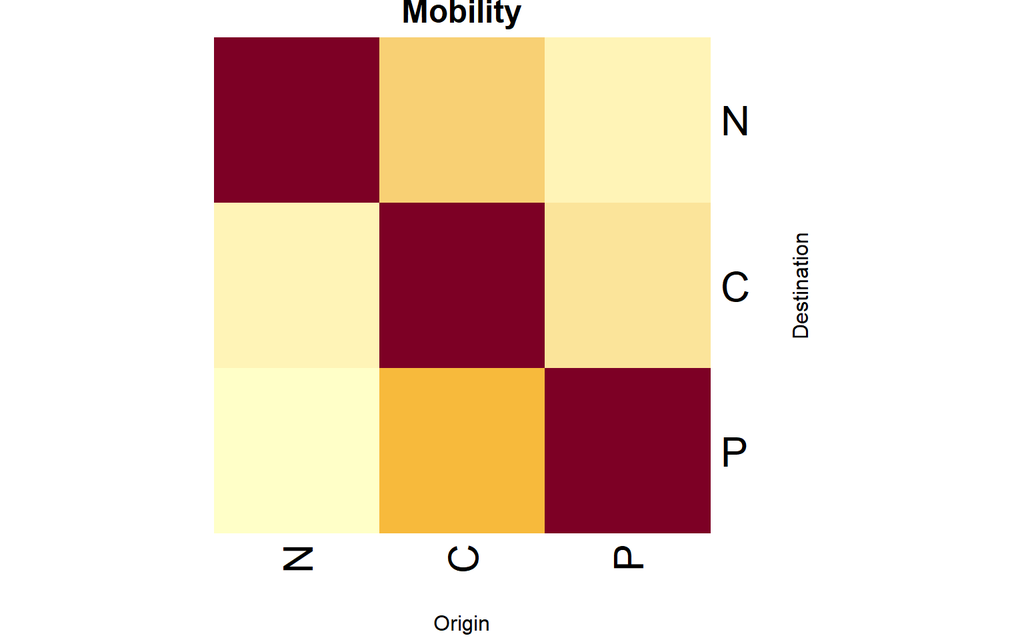

```r
heatmap(m,xlab="Origin",ylab="Destination",Colv = NA, Rowv = NA,revC = T,main="Mobility")
```

Now I will assess the correlation between co-presence and mobility in these 9 cells. The expectation is that co-presence to have the stronger on the diagonal and strongest for N to N cell.

```r
e<-read_dta("flow_exp_cor_by_educ.dta")
m<-matrix(e$cor,nrow=3)
row.names(m)<-c("N","C","P")
colnames(m)<-c("N","C","P")
print(m)
```

```
##           N         C         P
## N 0.3135925 0.2748853 0.2205631
## C 0.2682930 0.2823064 0.3298345
## P 0.5335242 0.2940726 0.2723693
```

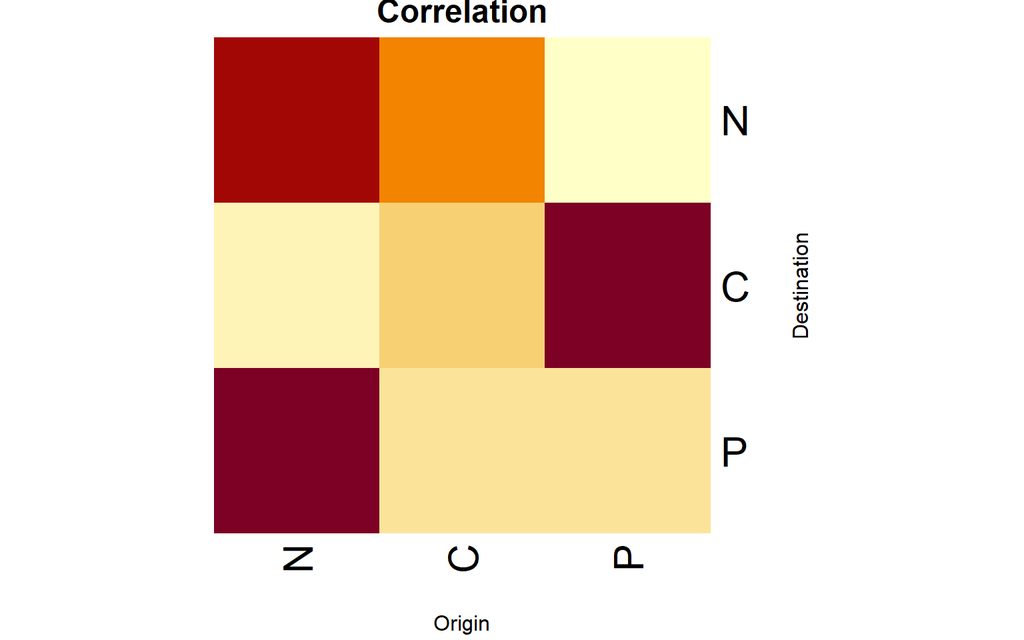

```r
heatmap(m,xlab="Origin",ylab="Destination",Colv = NA, Rowv = NA,revC = T,main="Correlation")
```

The pattern here is not super clean. First, the reason we see a strong correlation for N to P is mostly driven by health care and legal occupations, suggesting that our occupations for these industries could be too broad, and that some workers in non-credential occupations could be very well credentialed.A finding like this really suggests we should use more detailed categories.

Ignoring that specific cells, other results seem reason to me. Co-presence has greater effect for less credentialed occupations. It facilitates boundary-crossing between college and professional occupations but not so much between those who with a college degree and those without.

# Next Steps

I still have a few things on my todo list but I think it makes sense that we wait until implementing the new occupation scheme. My plan is to finalize what should go into the paper in my next write up and start working on the first draft.